# HW ARIMA

Donovan Kott

2023-11-20

```r
library(fpp2)
```

Import data set

```r
data2 <- read.csv("C:/Users/dmkot/Downloads/Unemployment in America Per US State.csv")
str(data2)
```

```
## 'data.frame':    29892 obs. of  11 variables:
##  $ FIPS.Code                                                : int  1 2 4 5 6 37 8 9 10 11 ...
##  $ State.Area                                               : chr  "Alabama" "Alaska" "Arizona" "Arkansas" ...
##  $ Year                                                     : int  1976 1976 1976 1976 1976 1976 1976 1976 1976 1976 ...
##  $ Month                                                    : int  1 1 1 1 1 1 1 1 1 1 ...
##  $ Total.Civilian.Non.Institutional.Population.in.State.Area: chr  "2,605,000   " "232,000   " "1,621,000   " "1,536,000   " ...
##  $ Total.Civilian.Labor.Force.in.State.Area                 : chr  "1,484,555   " "160,183   " "964,120   " "889,044   " ...
##  $ Percent.....of.State.Area.s.Population                   : num  57 69 59.5 57.9 62.6 64.1 67.2 64.2 62.7 64.4 ...
##  $ Total.Employment.in.State.Area                           : chr  "1,386,023   " "148,820   " "865,871   " "824,395   " ...
##  $ Percent.....of.Labor.Force.Employed.in.State.Area        : num  53.2 64.1 53.4 53.7 56.8 58.4 63.3 57.9 57.7 58.8 ...
##  $ Total.Unemployment.in.State.Area                         : chr  "98,532   " "11,363   " "98,249   " "64,649   " ...
##  $ Percent.....of.Labor.Force.Unemployed.in.State.Area      : num  6.6 7.1 10.2 7.3 9.2 8.9 5.8 9.8 8 8.7 ...
```

```r
data3 = data2[data2$State.Area == "New Jersey",]
head(data3)
```

```
##     FIPS.Code State.Area Year Month
## 32         34 New Jersey 1976     1
## 85         34 New Jersey 1976     2
## 138        34 New Jersey 1976     3
## 191        34 New Jersey 1976     4
## 244        34 New Jersey 1976     5
## 297        34 New Jersey 1976     6
##     Total.Civilian.Non.Institutional.Population.in.State.Area
## 32                                               5,358,000
## 85                                               5,363,000
## 138                                              5,367,000
## 191                                              5,372,000
## 244                                              5,376,000
## 297                                              5,381,000
##     Total.Civilian.Labor.Force.in.State.Area
```

[output cut: 34 more lines]

The time series plot shows signs of seasonality

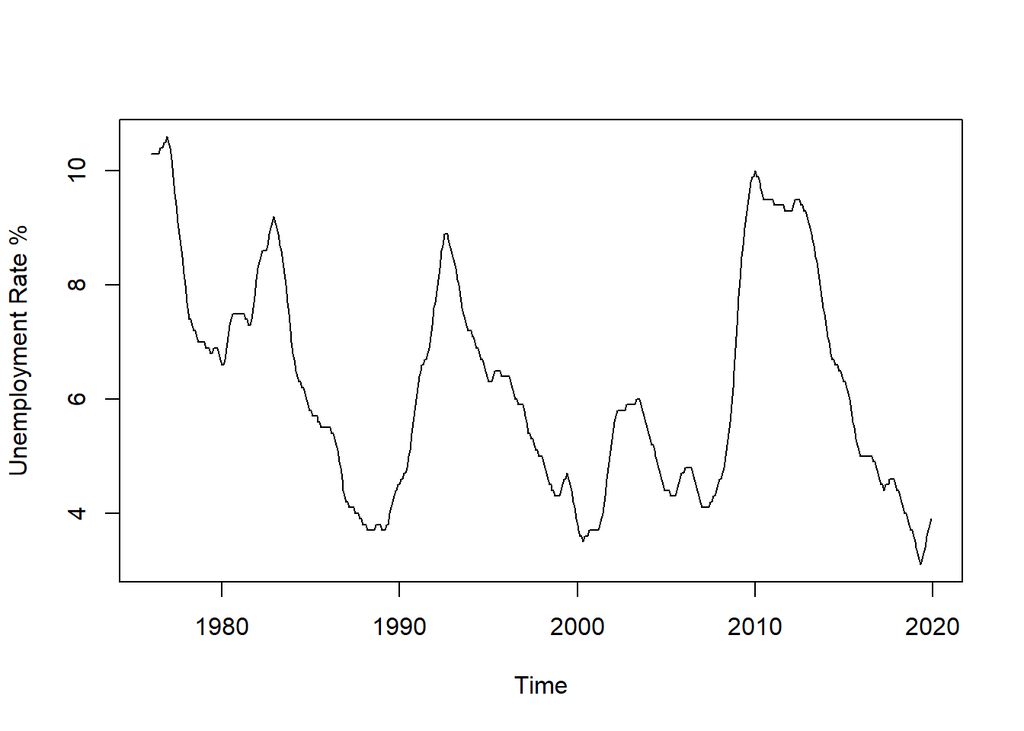

```r
myts = ts(data3$Percent.....of.Labor.Force.Unemployed.in.State.Area, start=c(1976,1), end=c(2019,12), frequency=12)
plot(myts, ylab="Unemployment Rate %")
```

The Acf shows 27 significant lag spikes

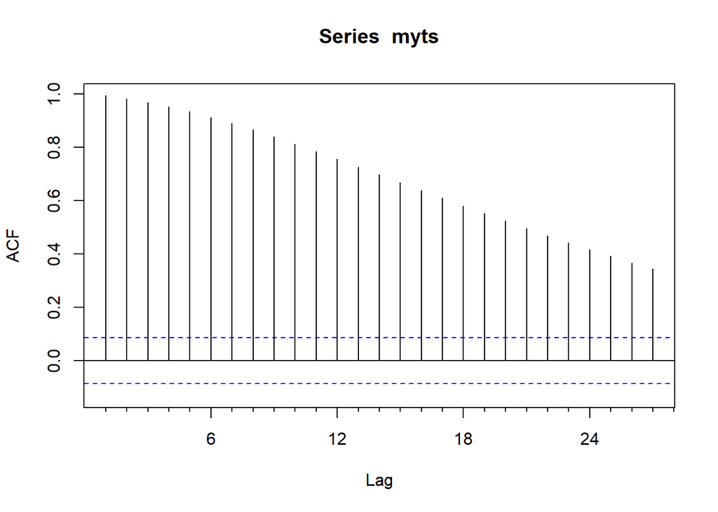

```r
Acf(myts)
```

Decomposition shows we have seasonality although the range is rather small. We have an additive time series.

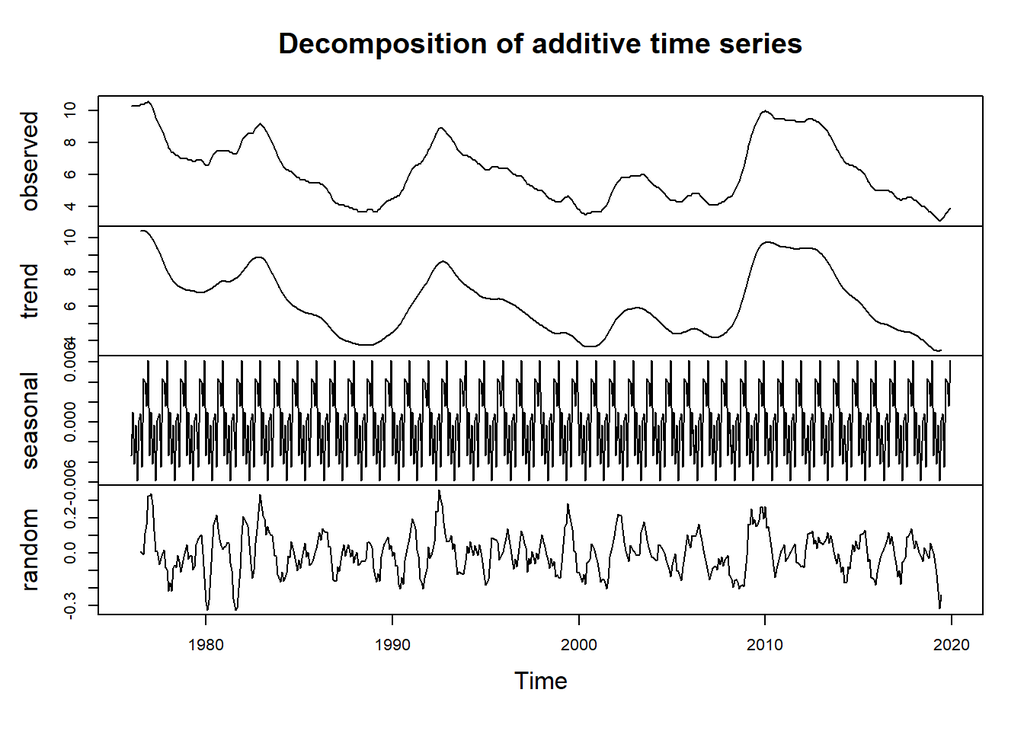

```r
plot(decompose(myts))
```

Number of differences required for a stationery series is 1.

```r
ndiffs(myts) #
```

```
## [1] 1
```

```r
nsdiffs(myts)
```

```
## [1] 0
```

There are quite a few signifcant lag spikes in the Acf and PAcf. When you remove the seasonality component it is 0

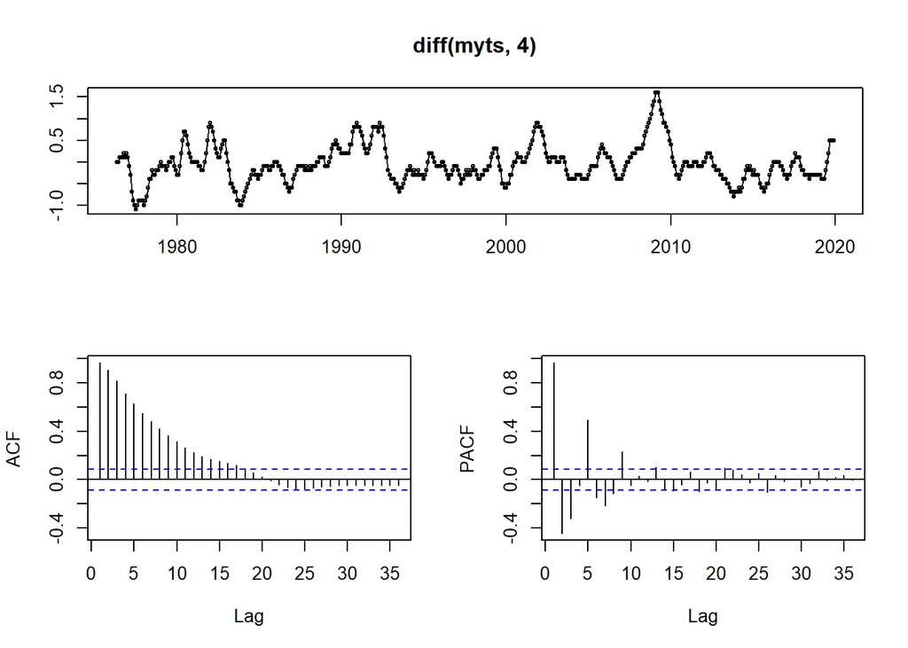

```r
tsdisplay(diff(myts,4))
```

```r
ndiffs(diff(myts,4))
```

```
## [1] 0
```

[figure not shown]

```r
tsdisplay(diff(diff(euretail,4)))
```

The best model is: ARIMA(1,1,2)(0,0,2)[12] The standard error is very very low. The sigma^2 is also very very low

```r
fit33=auto.arima(myts, stepwise=FALSE, approximation=FALSE, trace=TRUE)
```

```
##
##  ARIMA(0,1,0)                               : -744.7992
##  ARIMA(0,1,0)            with drift         : -748.2885
##  ARIMA(0,1,0)(0,0,1)[12]                    : -763.7835
##  ARIMA(0,1,0)(0,0,1)[12] with drift         : -765.2641
##  ARIMA(0,1,0)(0,0,2)[12]                    : -766.5208
##  ARIMA(0,1,0)(0,0,2)[12] with drift         : -768.6595
##  ARIMA(0,1,0)(1,0,0)[12]                    : -759.7661
##  ARIMA(0,1,0)(1,0,0)[12] with drift         : -761.4593
##  ARIMA(0,1,0)(1,0,1)[12]                    : -766.2786
##  ARIMA(0,1,0)(1,0,1)[12] with drift         : -768.1081
##  ARIMA(0,1,0)(1,0,2)[12]                    : -764.3096
##  ARIMA(0,1,0)(1,0,2)[12] with drift         : Inf
##  ARIMA(0,1,0)(2,0,0)[12]                    : -764.5948
##  ARIMA(0,1,0)(2,0,0)[12] with drift         : -766.717
##  ARIMA(0,1,0)(2,0,1)[12]                    : -764.2857
##  ARIMA(0,1,0)(2,0,1)[12] with drift         : -766.1752
##  ARIMA(0,1,0)(2,0,2)[12]                    : -788.3815
##  ARIMA(0,1,0)(2,0,2)[12] with drift         : Inf
##  ARIMA(0,1,1)                               : -971.6331
##  ARIMA(0,1,1)            with drift         : -973.3257
##  ARIMA(0,1,1)(0,0,1)[12]                    : -976.1124
##  ARIMA(0,1,1)(0,0,1)[12] with drift         : -977.0195
##  ARIMA(0,1,1)(0,0,2)[12]                    : -976.0834
##  ARIMA(0,1,1)(0,0,2)[12] with drift         : -977.3073
##  ARIMA(0,1,1)(1,0,0)[12]                    : -975.3703
##  ARIMA(0,1,1)(1,0,0)[12] with drift         : -976.3243
##  ARIMA(0,1,1)(1,0,1)[12]                    : -977.3622
##  ARIMA(0,1,1)(1,0,1)[12] with drift         : -978.4794
##  ARIMA(0,1,1)(1,0,2)[12]                    : -982.3233
##  ARIMA(0,1,1)(1,0,2)[12] with drift         : -984.7412
##  ARIMA(0,1,1)(2,0,0)[12]                    : -975.4505
##  ARIMA(0,1,1)(2,0,0)[12] with drift         : -976.6236
##  ARIMA(0,1,1)(2,0,1)[12]                    : -983.2138
##  ARIMA(0,1,1)(2,0,1)[12] with drift         : Inf
##  ARIMA(0,1,1)(2,0,2)[12]                    : -984.0377
##  ARIMA(0,1,1)(2,0,2)[12] with drift         : -986.3705
##  ARIMA(0,1,2)                               : -1153.903
##  ARIMA(0,1,2)            with drift         : -1154.829
##  ARIMA(0,1,2)(0,0,1)[12]                    : -1156.296
```

[output cut: 142 more lines]

```
##  ARIMA(3,1,2)            with drift         : -1393.904
##  ARIMA(4,1,0)                               : -1392.548
##  ARIMA(4,1,0)            with drift         : -1390.864
##  ARIMA(4,1,0)(0,0,1)[12]                    : -1392.512
##  ARIMA(4,1,0)(0,0,1)[12] with drift         : -1390.841
##  ARIMA(4,1,0)(1,0,0)[12]                    : -1392.208
##  ARIMA(4,1,0)(1,0,0)[12] with drift         : -1390.533
##  ARIMA(4,1,1)                               : -1390.583
##  ARIMA(4,1,1)            with drift         : -1388.902
##  ARIMA(5,1,0)                               : -1390.628
##  ARIMA(5,1,0)            with drift         : -1388.952
##
##
##
##  Best model: ARIMA(1,1,2)(0,0,2)[12]
```

```r
fit33
```

```
## Series: myts
## ARIMA(1,1,2)(0,0,2)[12]
##
## Coefficients:
##          ar1      ma1     ma2     sma1     sma2
##       0.8681  -0.4625  0.4215  -0.0660  -0.0946
## s.e.  0.0256   0.0437  0.0439   0.0461   0.0501
##
## sigma^2 = 0.004036:  log likelihood = 706.33
## AIC=-1400.66   AICc=-1400.5   BIC=-1375.06
```

There is no obvious pattern. The residuals appear to be random

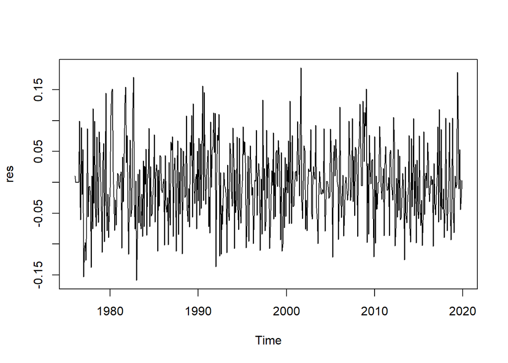

```r
res = residuals(fit33)
plot(res)
```

There is a significant lag spike at 23

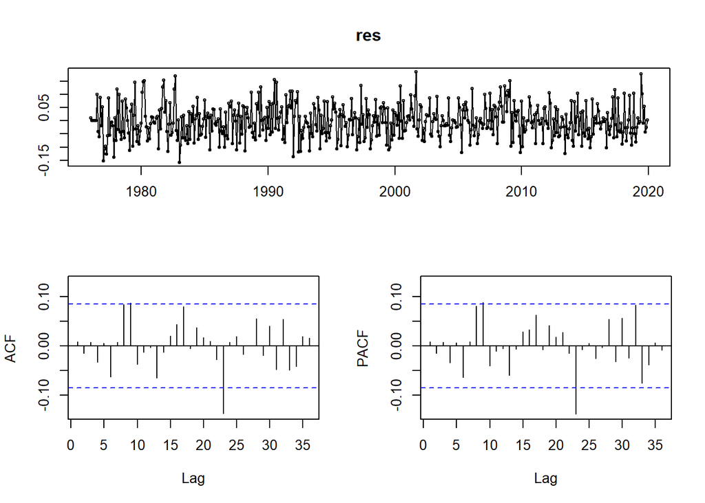

```r
tsdisplay(res)
```

The histogram of the residuals is normally distributed

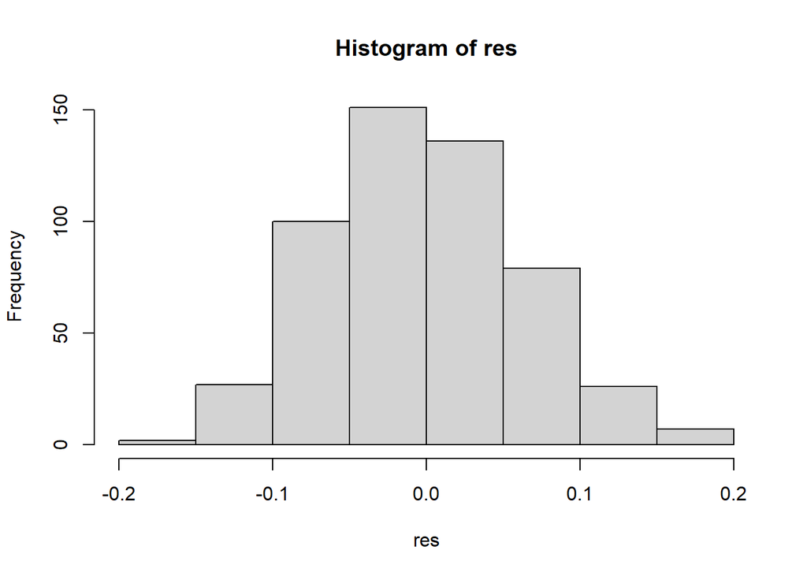

```r
hist(res)
```

Forecast for the next 24 months shows a slight upward trend then turns into a slow declining dip

```r
fcast=forecast(fit33,h=24)
plot(fcast)
```

[figure not shown]

The forecast appears to be extremely accurate since the red line (forecast) and black line (ts) are very similar

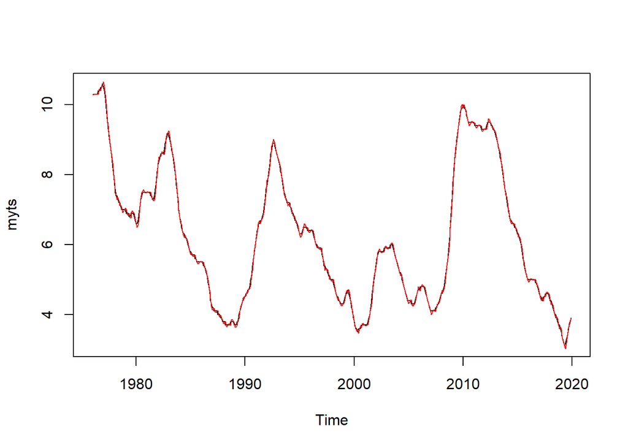

```r
plot(myts)
lines(fcast$fitted, col="red")
```

The RMSE is .063 which is extremely low. The Best model: ARIMA(1,1,2)(0,0,2)[12]

```r
accuracy(fcast)
```

```
##                        ME       RMSE        MAE          MPE      MAPE
## Training set -0.001829201 0.06316386 0.05041954 -0.005366392 0.8802321
##                    MASE       ACF1
## Training set 0.05766064 0.00865924
```